# Coefficient plots for linear models

Michael Friendly

2021-10-15

Coefficient plots are often more useful than tables but plotting *raw coefficients* can be misleading when the predictors are on different scales.

The packages `arm` and `modelsummary` are used to illustrate these plots, discovering some other problems with naive use of coefficient plots. I compare plotting:

- raw coefficients
- standardized coefficients
- meaningfully scaled coefficients

### Load packages

```r
library(arm)           # coefplot
library(modelsummary)  # model plot
library(dplyr)
library(ggplot2)
```

## Occupational prestige data

How does occupational prestige depend on education (years), income ($), %women, …?

I use a classic example from the `carData` package. The observations are averages for occupational categories rather than individuals. The data come from the 1971 Canadian census.

```r
data(Prestige, package="carData")
head(Prestige, 5)
```

```
##                     education income women prestige census type
## gov.administrators      13.11  12351 11.16     68.8   1113 prof
## general.managers        12.26  25879  4.02     69.1   1130 prof
## accountants             12.77   9271 15.70     63.4   1171 prof
## purchasing.officers     11.42   8865  9.11     56.8   1175 prof
## chemists                14.62   8403 11.68     73.5   2111 prof
```

## Fit a simple model

```r
mod0 <- lm(prestige ~ education + income + women,
           data=Prestige)
summary(mod0)
```

```
##
## Call:
## lm(formula = prestige ~ education + income + women, data = Prestige)
##
## Residuals:
##     Min      1Q  Median      3Q     Max
## -19.825  -5.333  -0.136   5.159  17.504
##
## Coefficients:
##              Estimate Std. Error t value Pr(>|t|)
## (Intercept) -6.794334   3.239089   -2.10    0.039 *
## education    4.186637   0.388701   10.77  < 2e-16 ***
## income       0.001314   0.000278    4.73  7.6e-06 ***
## women       -0.008905   0.030407   -0.29    0.770
## ---
## Signif. codes:  0 '***' 0.001 '**' 0.01 '*' 0.05 '.' 0.1 ' ' 1
##
## Residual standard error: 7.85 on 98 degrees of freedom
## Multiple R-squared:  0.798,  Adjusted R-squared:  0.792
## F-statistic:  129 on 3 and 98 DF,  p-value: <2e-16
```

## Visualize coefficients

The plots below show default coefficient plots for this model.

They are disappointing and misleading because these show the raw coefficients. It looks like only `education` has a non-zero effect. It is misleading because the predictors are on different scales, so it makes little sense to compare the change in `prestige` for a 1 year increase in `education` with the change for a $1 increase in `income`.

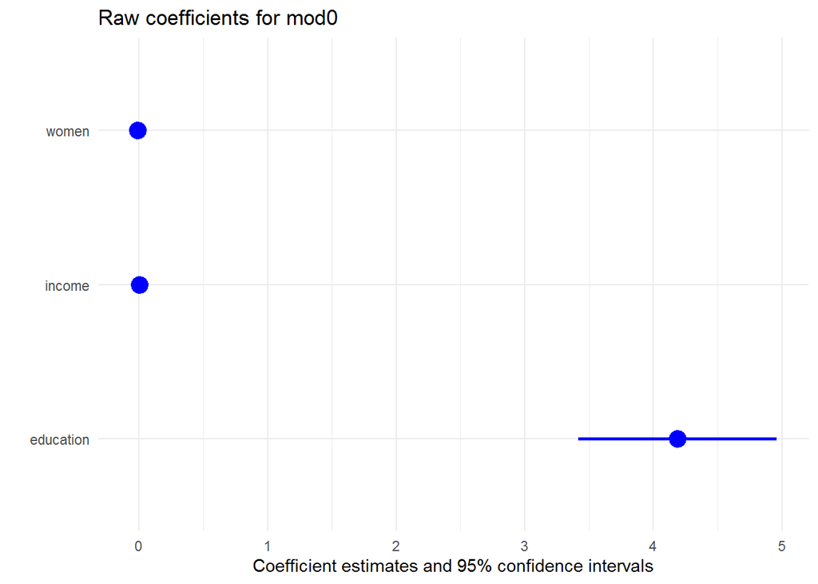

```r
modelplot(mod0, coef_omit="Intercept", color="blue", size=1) +
  labs(title="Raw coefficients for mod0")
```

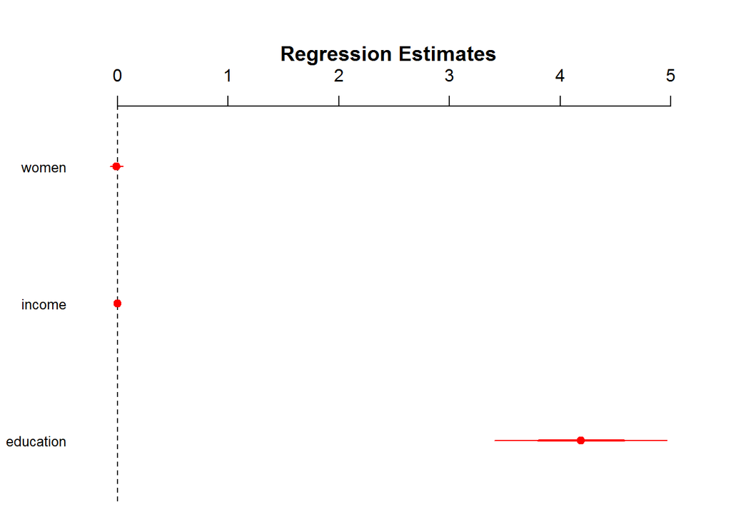

```r
arm::coefplot(mod0, col.pts="red", cex.pts=1.5)
```

## Fit a more complex model

Model `log(income)` and add an interaction with `type` of occupation.

```r
mod1 <- lm(prestige ~ education + women +
             log(income)*type, data=Prestige)
summary(mod1)
```

```
##
## Call:
## lm(formula = prestige ~ education + women + log(income) * type,
##     data = Prestige)
##
## Residuals:
##     Min      1Q  Median      3Q     Max
## -13.814  -4.685   0.656   3.966  16.569
##
## Coefficients:
##                       Estimate Std. Error t value Pr(>|t|)
## (Intercept)          -152.2059    23.2499   -6.55  3.5e-09 ***
## education               2.9282     0.5883    4.98  3.1e-06 ***
## women                   0.0883     0.0323    2.73   0.0076 **
## log(income)            18.9819     2.8285    6.71  1.7e-09 ***
## typeprof               85.2642    30.4582    2.80   0.0063 **
## typewc                 29.4133    36.5075    0.81   0.4226
## log(income):typeprof   -9.0124     3.4102   -2.64   0.0097 **
## log(income):typewc     -3.8334     4.2603   -0.90   0.3706
## ---
## Signif. codes:  0 '***' 0.001 '**' 0.01 '*' 0.05 '.' 0.1 ' ' 1
##
## Residual standard error: 6.27 on 90 degrees of freedom
##   (4 observations deleted due to missingness)
## Multiple R-squared:  0.875,  Adjusted R-squared:  0.865
## F-statistic: 90.1 on 7 and 90 DF,  p-value: <2e-16
```

## Compare models

Several packages allow to compare several models in the same plot.

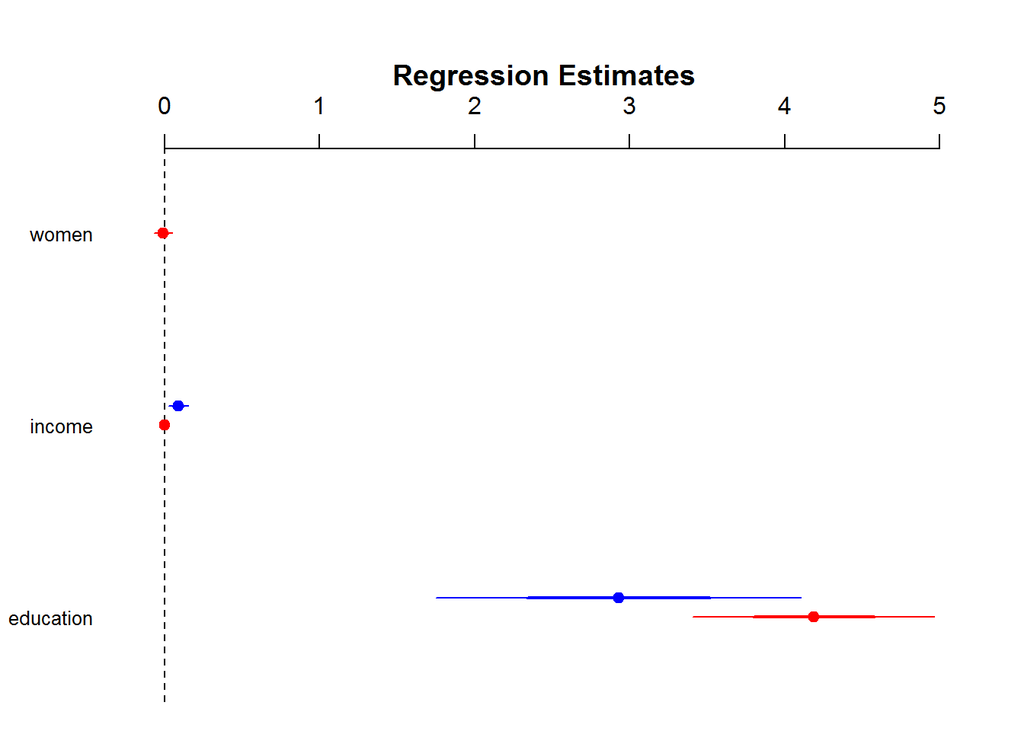

```r
arm::coefplot(mod0, col.pts="red", cex.pts=1.5)
arm::coefplot(mod1, add=TRUE, col.pts="blue", cex.pts=1.5)
```

But **WAIT**: `income` was entered as `log(income)` in `mod1`. It was stupid to try to compare the coefficients, but this should have raised an error.

## Standardize the variables, giving $\beta$ coefficients

An alternative is to present the standardized coefficients. These are interpreted as the standardized change in prestige for a one standard deviation change in the predictors.

One way to do this is to transform all variables to standardized ($z$) scores. The syntax ultimately uses `scale` to transform all the numeric variables.

```r
Prestige_std <- Prestige %>%
  as_tibble() %>%
  mutate(across(where(is.numeric), scale))
```

### Fit the same models to the standardized variables

This accords better with the fitted (standardized) coefficients. `income` and `education` are now both large and significant compared with the effect of `women`.

But a nagging doubt remains: How can I interpret the numerical **size** of coefficients?

```r
mod0_std <- lm(prestige ~ education + income + women,
               data=Prestige_std)

mod1_std <- lm(prestige ~ education + women +
             log(income)*type,
           data=Prestige_std)
#summary(mod1_std)
```

## Plot the standardized coefficients

These plots look more like what I was expecting to show the relative magnitudes of the coefficients and CIs so one could see which differ from zero.

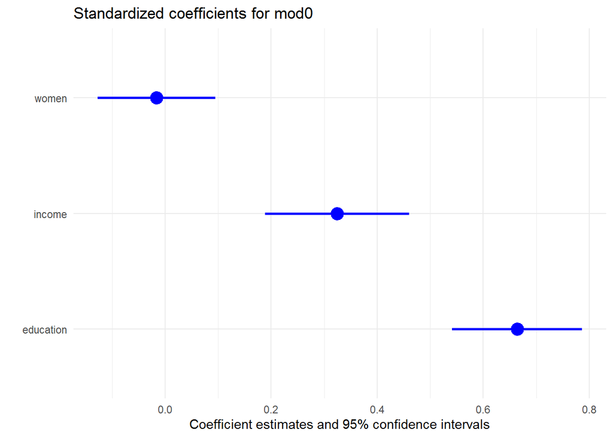

```r
modelplot(mod0_std, coef_omit="Intercept", color="blue", size=1) +
  labs(title="Standardized coefficients for mod0")
```

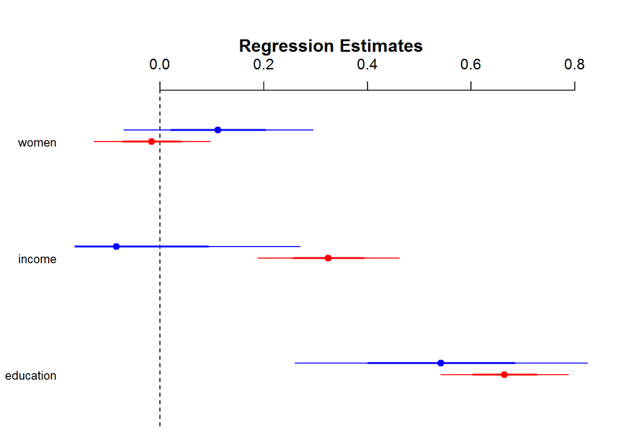

```r
arm::coefplot(mod0_std, col.pts="red", cex.pts=1.5)
arm::coefplot(mod1_std, add=TRUE, col.pts="blue", cex.pts=1.5)
```

## More meaningful units

Note that the effect of this is just to multiply the coefficients and their standard errors by a factor. The statistical conclusions of significance are unchanged.

```r
Prestige_scaled <- Prestige %>%
  mutate(education = 12 * education,
         income = income / 50,
         women = women / 10)

mod0_scaled <- lm(prestige ~ education + income + women,
               data=Prestige_scaled)

summary(mod0_scaled)
```

```
##
## Call:
## lm(formula = prestige ~ education + income + women, data = Prestige_scaled)
##
## Residuals:
##     Min      1Q  Median      3Q     Max
## -19.825  -5.333  -0.136   5.159  17.504
##
## Coefficients:
##             Estimate Std. Error t value Pr(>|t|)
## (Intercept)  -6.7943     3.2391   -2.10    0.039 *
## education     0.3489     0.0324   10.77  < 2e-16 ***
## income        0.0657     0.0139    4.73  7.6e-06 ***
## women        -0.0891     0.3041   -0.29    0.770
## ---
## Signif. codes:  0 '***' 0.001 '**' 0.01 '*' 0.05 '.' 0.1 ' ' 1
##
## Residual standard error: 7.85 on 98 degrees of freedom
## Multiple R-squared:  0.798,  Adjusted R-squared:  0.792
## F-statistic:  129 on 3 and 98 DF,  p-value: <2e-16
```

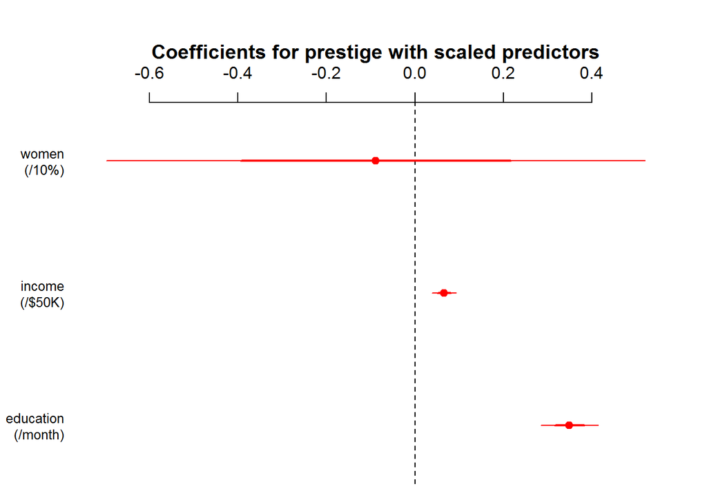

```r
arm::coefplot(mod0_scaled, col.pts="red", cex.pts=1.5,
              main = "Coefficients for prestige with scaled predictors",
              varnames=c("intercept",
                         "education\n(/month)",
                         "income\n(/$50K)",
                         "women\n(/10%)")
               )
```